# Spatial Analysis with sf

Marc Los Huertos

EA030 · Compiled 2026-10-24

EA030 — Advanced Statistics — Module 18

# Spatial Analysis: Working with Geographic Data in R

**Prof. Marc Los Huertos** • Pomona College

← Back to RTricks

> **What this module covers.** Temperature is not just a number — it is a number *at a location*. This module introduces the tools environmental scientists use to work with geographic data in R: the `sf` package for vector data (points, lines, polygons), coordinate reference systems (CRS), shapefiles, spatial joins, and choropleth mapping. A running example compares summer air temperatures across 10 US cities with contrasting land-use types, illuminating the **urban heat island effect**. The module closes with **kriging** — geostatistical interpolation that predicts temperatures at unmeasured locations by exploiting spatial autocorrelation.

## 1. Why Spatial Data Are Different

Every dataset you have worked with so far treats observations as **independent** — the value at row 27 tells you nothing about the value at row 28. Spatial data violates this assumption almost by definition. Tobler’s First Law of Geography states it plainly:

> *“Everything is related to everything else, but near things are more related than distant things.”* — Waldo Tobler, 1970

A temperature measurement in downtown Los Angeles is a better predictor of the temperature in a neighbouring parking lot than of the temperature in a forest 50 km away. This **spatial autocorrelation** is not a nuisance to eliminate — it is information to exploit. Kriging and spatial regression models do exactly that.

Spatial data also carry a property no other data type has: **location on a curved surface**. The Earth is not flat (apologies to anyone who thought this was a statistics tutorial), and representing curved-Earth coordinates on a flat screen or page requires a **projection** — a mathematical transformation that always introduces some distortion. Managing projections correctly is the single most common source of errors in spatial analysis.

### The three things that make spatial analysis special

**1. Spatial autocorrelation.** Values at nearby locations tend to be similar. Standard statistical tests assume independence; applying them naively to spatial data produces false precision (your effective sample size is smaller than it looks).

**2. The modifiable areal unit problem (MAUP).** When you aggregate point data into areas (census tracts, counties, watersheds), the results depend on *how* you draw the boundaries. The same underlying data can tell opposite stories depending on aggregation choices — a sobering fact for any policy analysis.

**3. Edge effects.** Locations near the boundary of your study area have fewer neighbours than interior locations. Spatial statistics that depend on neighbourhood relationships behave differently at edges, and ignoring this biases results.

**📌 Spatial data types: vector vs. raster**

Environmental spatial data come in two fundamental flavours. **Vector data** represent discrete objects: a weather station is a *point*, a river is a *line*, a watershed is a *polygon*. Each object carries attribute columns (like a spreadsheet row) alongside its geometry. The `sf` package handles vector data. **Raster data** divide space into a regular grid of cells, each storing one value (elevation, NDVI, land surface temperature). The `terra` and `stars` packages handle rasters. This module focuses on vector data; raster workflows appear in the Remote Sensing module.

## 2. Core Spatial Concepts

### 2.1 Geometry types

The `sf` package (Simple Features) represents spatial objects using five core geometry types. Every row in an `sf` data frame has one geometry:

| Type | Description | Environmental example |
| --- | --- | --- |
| `POINT` | Single (x, y) coordinate | Weather station, sampling site |
| `MULTIPOINT` | Set of points | Monitoring network |
| `LINESTRING` | Sequence of connected points | River reach, road |
| `POLYGON` | Closed ring of points | Watershed, city boundary, lake |
| `MULTIPOLYGON` | Collection of polygons | US state with islands |

### 2.2 The sf data frame

An `sf` object is a regular R data frame with one special column — conventionally named `geometry` — that stores the spatial information. Every other column is an ordinary attribute you can wrangle with `dplyr` verbs.

```r
# A typical sf object printed in the console
Simple feature collection with 10 features and 4 fields
Geometry type: POINT
Dimension:     XY
Bounding box:  xmin: -118.2 ymin: 29.7 xmax: -71.1 ymax: 47.6
CRS:           EPSG:4326
# A tibble: 10 × 5
  city          temp_C landuse   pop_million geometry
  <chr>          <dbl> <chr>           <dbl> <POINT [°]>
1 Los Angeles     32.1 Urban             3.9 (-118.24 34.05)
2 Phoenix         41.3 Urban             1.6 (-112.07 33.45)
...
```

The `geometry` column is “sticky” — it travels with the data frame through `filter()`, `mutate()`, `left_join()`, and most `dplyr` operations automatically.

### 2.3 Spatial relationships

`sf` provides predicate functions that test geometric relationships:

| Function | Tests whether… | Use case |
| --- | --- | --- |
| `st_intersects()` | geometries share any point | Does this watershed touch this county? |
| `st_within()` | A is fully inside B | Which stations are within city limits? |
| `st_contains()` | B fully contains A | Which counties contain a monitoring site? |
| `st_distance()` | Computes pairwise distances | How far is each station from the coast? |
| `st_buffer()` | Creates a buffer zone | 1 km buffer around each industrial facility |

## 3. Shapefiles: What They Are and Why They Come in Folders

The **shapefile** is the most common vector data format in environmental science, developed by Esri in the early 1990s and now effectively a universal standard. Every EPA monitoring dataset, USGS watershed boundary, and Census TIGER file you will download comes as a shapefile — and every shapefile is actually **four or more files that must stay together**.

Geometry

.shp  
The actual shapes — coordinates of every point, line, or polygon vertex. The file everyone calls “the shapefile.”

Index

.shx  
A positional index that lets software jump directly to a specific feature’s geometry without reading the whole .shp file.

Attributes

.dbf  
A dBASE IV table storing all non-spatial columns. This is your spreadsheet — names, values, categories — one row per feature.

Projection

.prj  
A plain-text file describing the coordinate reference system. Without this, software cannot place your features on Earth correctly.

Spatial index

.sbn / .sbx  
Optional Esri spatial index files that speed up spatial queries. Not required by sf.

Encoding

.cpg  
Specifies the character encoding for the .dbf attribute names (e.g., UTF-8). Prevents garbled accented characters.

**⚠️ The shapefile folder rule**

All files with the same base name must be in the same directory. If a colleague emails you `watersheds.shp` alone, you cannot read it — you need `watersheds.shp`, `watersheds.shx`, `watersheds.dbf`, and `watersheds.prj` at minimum. When sharing shapefiles, always zip the entire folder. When reading with `sf::st_read()`, point to the `.shp` file and sf loads the rest automatically.

### Reading and writing shapefiles with sf

```r
library(sf)

# Reading — point to the .shp file; sf loads .dbf, .prj, .shx automatically
watersheds <- st_read("data/shapefiles/watersheds.shp")

# sf also reads GeoJSON (single file, easier to share):
stations   <- st_read("data/stations.geojson")

# Writing back out
st_write(watersheds, "outputs/watersheds_clean.shp")       # shapefile
st_write(watersheds, "outputs/watersheds_clean.geojson")   # GeoJSON
st_write(watersheds, "outputs/watersheds_clean.gpkg")      # GeoPackage (preferred modern format)
```

**💡 Prefer GeoPackage over shapefile for new work**

The **GeoPackage** (`.gpkg`) format is a modern single-file alternative to the shapefile that supports longer column names (shapefile truncates to 10 characters!), UTF-8 natively, multiple layers per file, and files larger than 2 GB. `sf` reads and writes GeoPackage with the same `st_read()` / `st_write()` calls.

## 4. Coordinate Reference Systems

A **coordinate reference system (CRS)** is the mathematical framework that maps (x, y) numbers to locations on Earth. Getting CRS management wrong is the most common way spatial analyses go silently wrong — two layers that look identical in print but use different CRS will appear in completely different parts of the globe when overlaid.

### 4.1 Geographic vs. projected CRS

**Geographic CRS** (also called *unprojected* or *lat/lon*) stores locations as longitude and latitude in decimal degrees. The most common is **WGS 84** (EPSG:4326), used by GPS devices worldwide and by most downloaded datasets. Distances in degrees are meaningless for area calculations — a degree of longitude near the equator covers ~111 km, but near the poles it covers nearly zero.

**Projected CRS** transforms the curved Earth onto a flat plane, with coordinates in metres (or feet). Now distances and areas are meaningful. The choice of projection always involves a trade-off:

| Projection family | Preserves | Distorts | Good for |
| --- | --- | --- | --- |
| Conformal (e.g., UTM, State Plane) | Angles / shape | Area | Navigation, local mapping |
| Equal-area (e.g., Albers, Mollweide) | Area | Shape | National statistics, choropleth maps |
| Equidistant | Distance from centre | Area and shape | Distance calculations |

### 4.2 EPSG codes: the universal shorthand

Every standard CRS has an **EPSG code** — a four- or five-digit number that uniquely identifies it. This is the most reliable way to specify a CRS in code.

| EPSG | Name | Common use |
| --- | --- | --- |
| 4326 | WGS 84 (lat/lon) | GPS, most downloaded data, web maps |
| 3857 | Web Mercator | Google Maps, OpenStreetMap tile backgrounds |
| 5070 | NAD83 / Conus Albers | Continental US equal-area analysis |
| 32610–32619 | UTM Zone 10N–19N | Accurate local distance/area in western US |
| 26910–26919 | NAD83 UTM Zone 10N–19N | USGS topographic data |

### 4.3 CRS operations in sf

```r
library(sf)

# Check the CRS of an object
st_crs(my_sf)

# Transform to a different CRS
# Always transform, never assign unless you are fixing a wrongly-labelled CRS
my_sf_albers <- st_transform(my_sf, crs = 5070)   # NAD83 Conus Albers
my_sf_utm    <- st_transform(my_sf, crs = 32611)   # UTM Zone 11N

# WRONG — do not do this unless the CRS label is simply incorrect:
st_crs(my_sf) <- 4326   # only to fix a mis-labelled CRS, not to reproject
```

**⚠️ st_transform() vs. assigning st_crs() — a critical distinction**

`st_transform(sf, crs)` **reprojects** the coordinates — it moves the points on Earth to match the new system. `st_crs(sf) <- crs` only **relabels** the CRS without moving anything. If you use the assignment form on correctly-labelled data, you will silently place your features in the wrong location on the globe. Always use `st_transform()` for reprojection.

## 5. Data Setup: Urban Heat Islands Across 10 US Cities

The **urban heat island (UHI) effect** describes how cities are systematically warmer than surrounding rural areas. Impervious surfaces (concrete, asphalt) absorb heat; sparse vegetation provides less evaporative cooling; waste heat from vehicles and air conditioners adds further energy. The effect is strongest on calm, clear summer nights and can exceed 10°C in large cities.

We will simulate a realistic dataset of 10 US cities with contrasting land-use compositions, multiple monitoring stations per city, and summer afternoon temperatures. This dataset is constructed to be analytically identical to what you would obtain from EPA AQS or the National Land Cover Database (NLCD).

```r
library(sf)         # vector spatial data
library(dplyr)
library(tidyr)
library(ggplot2)
library(viridis)    # perceptually uniform colour scales
library(knitr)
library(kableExtra)
# gstat and sp are used for kriging (Section 9)
# install.packages(c("gstat", "sp")) if needed
```

```r
set.seed(2024)

# ── City metadata ────────────────────────────────────────────────────────────
cities <- data.frame(
  city        = c("Los Angeles", "Phoenix", "Houston", "Chicago",
                  "New York",    "Seattle", "Denver",  "Atlanta",
                  "Minneapolis", "Portland"),
  lon         = c(-118.24, -112.07, -95.37, -87.63,
                  -74.01,  -122.33,  -104.99, -84.39,
                  -93.27,  -122.68),
  lat         = c(34.05,  33.45,  29.76,  41.88,
                  40.71,  47.61,   39.74,  33.75,
                  44.98,  45.52),
  # Fraction of impervious surface in urban core (0–1)
  imperv_frac = c(0.72, 0.78, 0.65, 0.61,
                  0.80, 0.52, 0.55, 0.58,
                  0.60, 0.49),
  # Fraction of tree canopy cover in urban core (0–1)
  canopy_frac = c(0.18, 0.08, 0.22, 0.19,
                  0.21, 0.38, 0.25, 0.35,
                  0.28, 0.42),
  # Climate zone affects baseline temperature
  climate     = c("Mediterranean", "Desert", "Humid subtropical", "Continental",
                  "Continental",   "Oceanic", "Semi-arid", "Humid subtropical",
                  "Continental",  "Oceanic"),
  # Mean July afternoon temperature (°C) at a reference rural station nearby
  rural_temp_C = c(29.8, 40.2, 33.1, 28.4,
                   28.9, 22.6, 31.4, 32.7,
                   27.8, 23.5)
)

# ── Simulate monitoring stations within each city ────────────────────────────
# Each city has 6–10 stations with varying land-use fractions
n_stations_per_city <- sample(6:10, nrow(cities), replace = TRUE)

stations <- do.call(rbind, lapply(seq_len(nrow(cities)), function(i) {
  n  <- n_stations_per_city[i]
  ct <- cities[i, ]

  # Randomly vary impervious fraction across stations within the city
  imp  <- pmin(pmax(ct$imperv_frac + rnorm(n, 0, 0.12), 0.05), 0.98)
  can  <- pmin(pmax(ct$canopy_frac + rnorm(n, 0, 0.08), 0.01), 0.70)

  # Temperature model:
  # base = rural temp + UHI from impervious - cooling from canopy + noise
  uhi_effect <- 6.5 * imp - 3.2 * can
  temp_C     <- ct$rural_temp_C + uhi_effect + rnorm(n, 0, 0.8)

  # Scatter stations within ~0.15 degrees of city centre
  data.frame(
    city        = ct$city,
    station_id  = paste0(substr(ct$city, 1, 3), "_", sprintf("%02d", seq_len(n))),
    lon         = ct$lon + runif(n, -0.15, 0.15),
    lat         = ct$lat + runif(n, -0.12, 0.12),
    imperv_frac = round(imp, 3),
    canopy_frac = round(can, 3),
    temp_C      = round(temp_C, 2),
    rural_temp_C = ct$rural_temp_C,
    uhi_C       = round(temp_C - ct$rural_temp_C, 2),
    climate     = ct$climate
  )
}))

cat("Total monitoring stations:", nrow(stations), "\n")
```

```
## Total monitoring stations: 82
```

```r
cat("Cities:", nrow(cities), "\n")
```

```
## Cities: 10
```

```r
stations |>
  group_by(city) |>
  summarise(
    n           = n(),
    mean_temp   = round(mean(temp_C), 1),
    mean_uhi    = round(mean(uhi_C),  1),
    mean_imperv = round(mean(imperv_frac) * 100, 0),
    mean_canopy = round(mean(canopy_frac) * 100, 0)
  ) |>
  arrange(desc(mean_temp)) |>
  kable(col.names = c("City", "Stations", "Mean temp (°C)",
                       "Mean UHI (°C)", "% Impervious", "% Canopy"),
        caption = "Summary of simulated urban temperature monitoring data across 10 US cities.") |>
  kable_styling(bootstrap_options = "striped")
```

Summary of simulated urban temperature monitoring data across 10 US cities.

| City | Stations | Mean temp (°C) | Mean UHI (°C) | % Impervious | % Canopy |
| --- | --- | --- | --- | --- | --- |
| Phoenix | 10 | 44.1 | 3.9 | 70 | 9 |
| Houston | 10 | 35.4 | 2.3 | 60 | 26 |
| Atlanta | 7 | 35.0 | 2.3 | 59 | 40 |
| Denver | 6 | 34.7 | 3.3 | 64 | 25 |
| Los Angeles | 7 | 34.0 | 4.2 | 73 | 21 |
| New York | 6 | 33.9 | 5.0 | 80 | 22 |
| Chicago | 9 | 31.6 | 3.2 | 57 | 16 |
| Minneapolis | 7 | 30.2 | 2.4 | 58 | 31 |
| Portland | 10 | 25.4 | 1.9 | 52 | 45 |
| Seattle | 10 | 25.2 | 2.6 | 54 | 36 |

## 6. sf Basics: Building and Exploring Spatial Objects

### 6.1 Creating an sf object from a data frame

Any data frame with longitude and latitude columns can be converted to an `sf` point object with `st_as_sf()`. You must specify which columns hold the coordinates and what CRS those coordinates use.

```r
library(sf)

# Convert monitoring stations to sf POINT object
# coords = c("lon", "lat") tells sf which columns are x and y
# crs = 4326 means WGS 84 geographic coordinates (decimal degrees)
stations_sf <- st_as_sf(stations,
                         coords = c("lon", "lat"),
                         crs    = 4326)

# The geometry column is now attached
print(stations_sf[1:4, c("station_id", "city", "temp_C", "geometry")])
```

```
## Simple feature collection with 4 features and 3 fields
## Geometry type: POINT
## Dimension:     XY
## Bounding box:  xmin: -118.384 ymin: 34.0036 xmax: -118.1752 ymax: 34.12556
## Geodetic CRS:  WGS 84
##   station_id        city temp_C                   geometry
## 1     Los_01 Los Angeles  34.78 POINT (-118.1752 34.01939)
## 2     Los_02 Los Angeles  34.99  POINT (-118.384 34.08346)
## 3     Los_03 Los Angeles  34.80  POINT (-118.3324 34.0036)
## 4     Los_04 Los Angeles  32.52 POINT (-118.2531 34.12556)
```

```r
# Check geometry type and CRS
st_geometry_type(stations_sf)[1]
```

```
## [1] POINT
## 18 Levels: GEOMETRY POINT LINESTRING POLYGON MULTIPOINT ... TRIANGLE
```

```r
st_crs(stations_sf)$epsg
```

```
## [1] 4326
```

```r
# Bounding box of the dataset
st_bbox(stations_sf)
```

```
##       xmin       ymin       xmax       ymax
## -122.82237   29.66351  -73.86421   47.72826
```

### 6.2 Plotting sf objects: a first map

`sf` provides a simple `plot()` method that maps each attribute column:

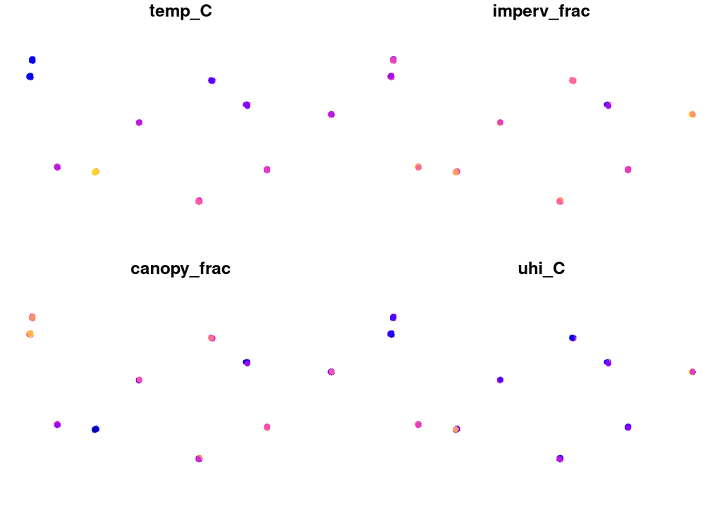

Quick sf plot of monitoring station temperatures. Each panel maps one attribute variable. The default colour scale is applied automatically. For publication-quality maps we will use ggplot2 in Section 7.

```r
# Quick exploratory plot — one panel per attribute column
plot(stations_sf[, c("temp_C", "imperv_frac", "canopy_frac", "uhi_C")],
     pch = 16, cex = 0.9)
```

### 6.3 Summarising spatial data: city centroids

We can compute city-level summaries and build a second `sf` object representing city centroids — which we will use for choropleth mapping.

```r
# City-level aggregates
city_summary <- stations |>
  group_by(city) |>
  summarise(
    n_stations  = n(),
    mean_temp   = mean(temp_C),
    mean_uhi    = mean(uhi_C),
    mean_imperv = mean(imperv_frac),
    mean_canopy = mean(canopy_frac),
    rural_temp  = first(rural_temp_C),
    climate     = first(climate),
    # Keep city centre coordinates from the original cities data frame
    lon         = mean(lon),
    lat         = mean(lat)
  ) |>
  left_join(cities[, c("city","lon","lat")], by = "city", suffix = c("_mean","")) |>
  select(-lon_mean, -lat_mean)

city_sf <- st_as_sf(city_summary, coords = c("lon", "lat"), crs = 4326)
```

## 7. Choropleth Maps with ggplot2 and sf

A **choropleth map** fills geographic areas with colour to represent a variable. `ggplot2` integrates with `sf` through `geom_sf()`, which reads the geometry column automatically and handles all projection details.

### 7.1 Station-level temperature map

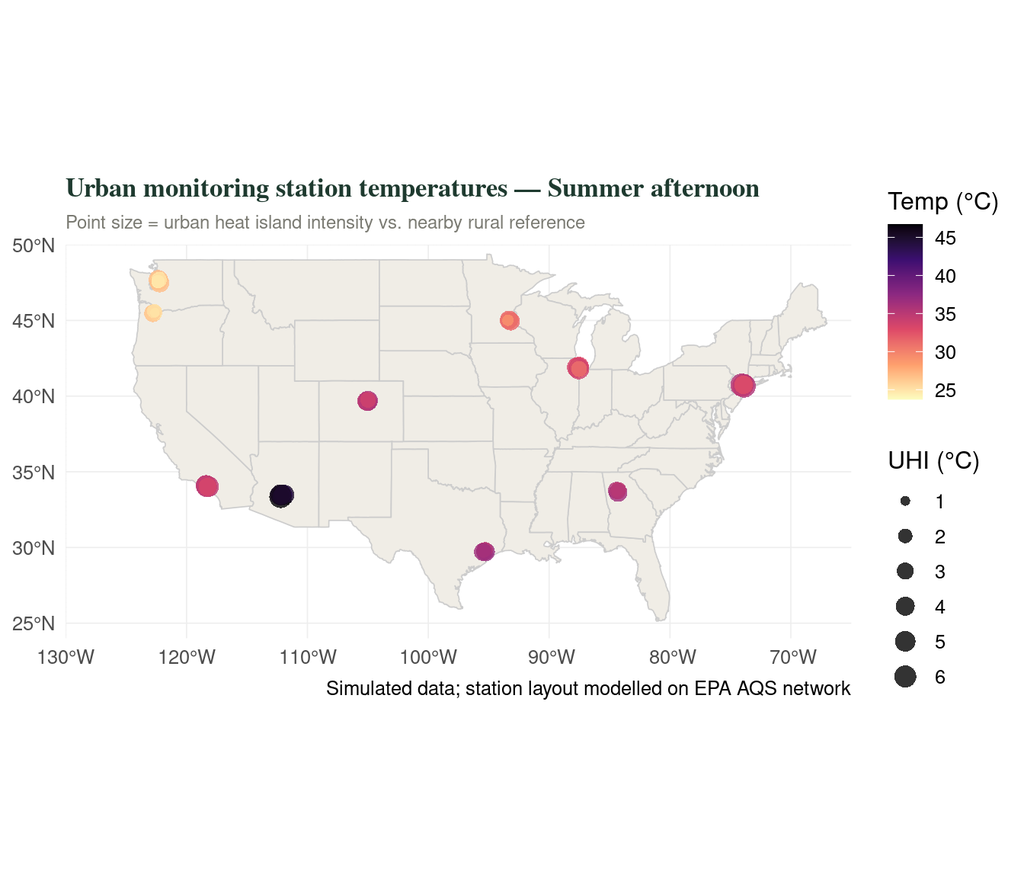

```r
# US state boundaries for context — built into the maps package
us_states <- st_as_sf(maps::map("state", plot = FALSE, fill = TRUE))
us_states <- st_transform(us_states, crs = 4326)

ggplot() +
  geom_sf(data = us_states, fill = "#f0ede6", colour = "#ccc", linewidth = 0.3) +
  geom_sf(data = stations_sf,
          aes(colour = temp_C, size = pmax(uhi_C, 0)),
          alpha = 0.80, shape = 16) +
  scale_colour_viridis_c(option = "magma", name = "Temp (°C)",
                          direction = -1) +
  scale_size_continuous(name = "UHI (°C)", range = c(1.5, 5)) +
  coord_sf(xlim = c(-130, -65), ylim = c(24, 50), expand = FALSE) +
  labs(
    title    = "Urban monitoring station temperatures — Summer afternoon",
    subtitle = "Point size = urban heat island intensity vs. nearby rural reference",
    caption  = "Simulated data; station layout modelled on EPA AQS network"
  ) +
  theme_minimal(base_size = 12) +
  theme(
    plot.title    = element_text(family = "serif", face = "bold",
                                  colour = "#1e3a2f", size = 13),
    plot.subtitle = element_text(colour = "#7a7a72", size = 9),
    legend.position = "right",
    panel.grid = element_line(colour = "#eee", linewidth = 0.3)
  )
```

### 7.2 Choropleth of mean UHI by city

A choropleth works best when the geographic units are polygons. Here we create circular buffer polygons around each city centre to give the map more visual weight. In a real analysis you would use actual city boundary polygons downloaded from the Census Bureau.

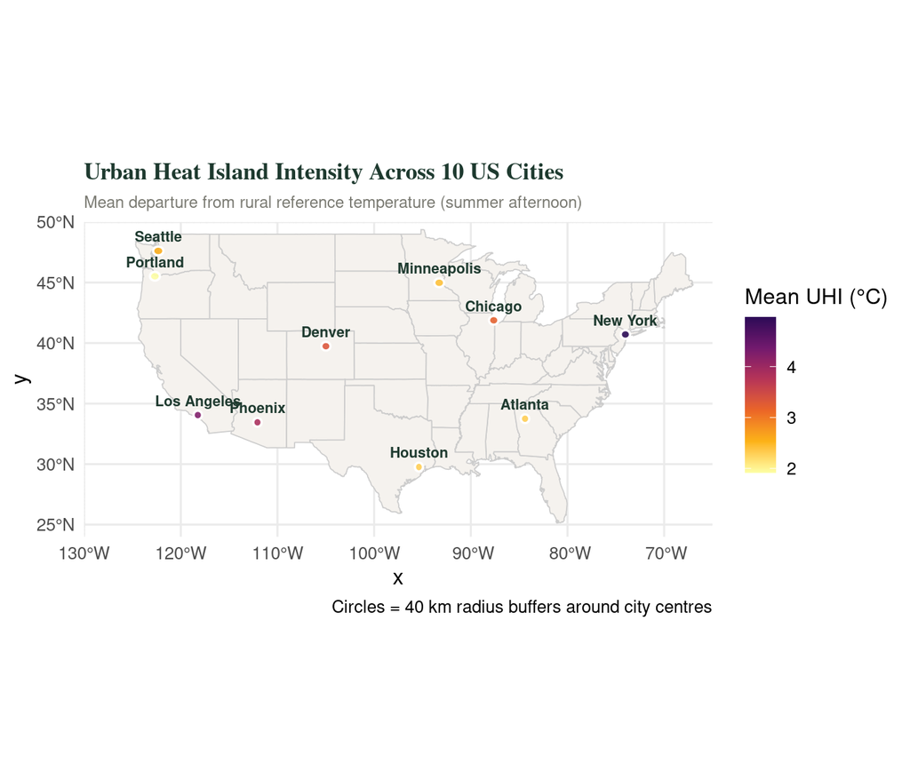

```r
# Reproject to Albers equal-area for buffering (distances in metres)
city_albers <- st_transform(city_sf, crs = 5070)

# 40 km radius buffer around each city centre
city_circles <- st_buffer(city_albers, dist = 40000)

# Back to geographic CRS for plotting
city_circles <- st_transform(city_circles, crs = 4326)

ggplot() +
  geom_sf(data = us_states, fill = "#f5f2ee", colour = "#ccc", linewidth = 0.3) +
  geom_sf(data = city_circles,
          aes(fill = mean_uhi),
          colour = "white", linewidth = 0.6, alpha = 0.88) +
  geom_sf_text(data = city_sf, aes(label = city),
               size = 2.8, colour = "#1e3a2f", fontface = "bold",
               nudge_y = 1.2) +
  scale_fill_viridis_c(option = "inferno", name = "Mean UHI (°C)",
                        direction = -1, begin = 0.15) +
  coord_sf(xlim = c(-130, -65), ylim = c(24, 50), expand = FALSE) +
  labs(
    title   = "Urban Heat Island Intensity Across 10 US Cities",
    subtitle = "Mean departure from rural reference temperature (summer afternoon)",
    caption  = "Circles = 40 km radius buffers around city centres"
  ) +
  theme_minimal(base_size = 12) +
  theme(
    plot.title    = element_text(family = "serif", face = "bold",
                                  colour = "#1e3a2f", size = 13),
    plot.subtitle = element_text(colour = "#7a7a72", size = 9),
    legend.position = "right"
  )
```

## 8. Spatial Joins: Linking Layers by Location

A **spatial join** merges two `sf` objects based on geographic relationship rather than a shared column. The canonical use: you have monitoring stations (points) and you want to attach attributes from the watershed or county polygon they fall within.

### 8.1 How st_join() works

```r
# Syntax mirrors dplyr::left_join() but uses geometry instead of a key column
result <- st_join(points_sf, polygons_sf, join = st_within)
# result has all rows of points_sf, with polygon attributes appended
# where each point falls within a polygon
```

### 8.2 Joining stations to climate zones

We simulate a simple climate zone polygon layer and join it to our stations, then test whether UHI intensity differs by climate.

```r
# Create simple rectangular climate zone polygons for illustration
# In practice you would load a real climate classification shapefile (e.g. Koppen-Geiger)
climate_boxes <- data.frame(
  zone   = c("Hot arid", "Subtropical", "Continental", "Oceanic/Mediterranean"),
  xmin   = c(-115, -100, -100, -130),
  xmax   = c( -100, -80,  -70, -100),
  ymin   = c(  25,   25,   38,   30),
  ymax   = c(  40,   38,   50,   50)
)

climate_sf <- do.call(rbind, lapply(seq_len(nrow(climate_boxes)), function(i) {
  r <- climate_boxes[i, ]
  geom <- st_polygon(list(matrix(
    c(r$xmin, r$ymin,
      r$xmax, r$ymin,
      r$xmax, r$ymax,
      r$xmin, r$ymax,
      r$xmin, r$ymin),
    ncol = 2, byrow = TRUE
  )))
  st_sf(zone = r$zone, geometry = st_sfc(geom, crs = 4326))
}))
```

```r
# Join each station to its climate zone polygon
stations_joined <- st_join(stations_sf, climate_sf, join = st_within)

# Summarise UHI by climate zone
uhi_by_zone <- stations_joined |>
  st_drop_geometry() |>          # remove geometry for plain dplyr operations
  group_by(zone) |>
  summarise(
    n         = n(),
    mean_uhi  = round(mean(uhi_C, na.rm = TRUE), 2),
    sd_uhi    = round(sd(uhi_C,   na.rm = TRUE), 2),
    mean_imperv = round(mean(imperv_frac) * 100, 1)
  ) |>
  arrange(desc(mean_uhi))

kable(uhi_by_zone,
      col.names = c("Climate zone", "Stations", "Mean UHI (°C)", "SD", "% Impervious"),
      caption   = "Urban heat island intensity by climate zone after spatial join.")
```

Urban heat island intensity by climate zone after spatial join.

| Climate zone | Stations | Mean UHI (°C) | SD | % Impervious |
| --- | --- | --- | --- | --- |
| Hot arid | 16 | 3.68 | 1.20 | 67.7 |
| Continental | 22 | 3.44 | 1.73 | 63.9 |
| Oceanic/Mediterranean | 43 | 3.11 | 1.33 | 61.7 |
| Subtropical | 17 | 2.31 | 0.83 | 59.9 |

**📌 st_drop_geometry()**

Once you have finished spatial operations, call `st_drop_geometry()` to convert an `sf` object back to a plain data frame. This speeds up subsequent non-spatial operations and prevents the geometry column from appearing unexpectedly in output tables.

### 8.3 Visualising the spatial join result

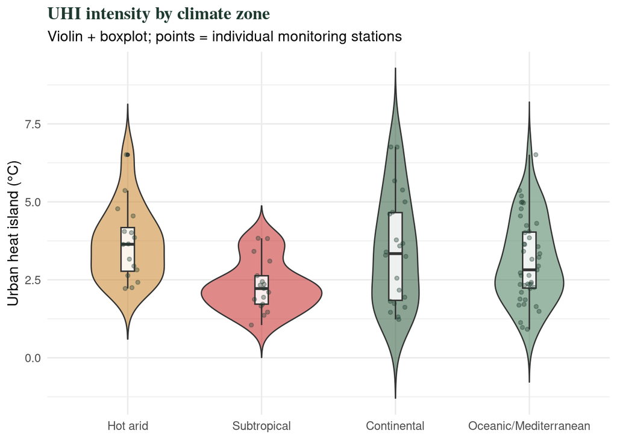

Urban heat island intensity by climate zone. Hot arid cities (Phoenix) show the strongest UHI; oceanic/Mediterranean cities (Seattle, Portland, Los Angeles) show weaker effects partly because lower baseline humidity and higher canopy cover moderate surface temperatures. Points are jittered to show all individual stations.

```r
stations_joined |>
  st_drop_geometry() |>
  filter(!is.na(zone)) |>
  mutate(zone = factor(zone, levels = c("Hot arid","Subtropical",
                                         "Continental","Oceanic/Mediterranean"))) |>
  ggplot(aes(x = zone, y = uhi_C, fill = zone)) +
  geom_violin(trim = FALSE, alpha = 0.55, linewidth = 0.5) +
  geom_boxplot(width = 0.10, fill = "white", alpha = 0.85, outlier.size = 1) +
  geom_jitter(width = 0.08, alpha = 0.35, size = 1.2, colour = "#1e3a2f") +
  scale_fill_manual(values = c("#c8832a","#c62828","#2d5a3d","#4a7c5e"), guide = "none") +
  labs(x = NULL, y = "Urban heat island (°C)",
       title = "UHI intensity by climate zone",
       subtitle = "Violin + boxplot; points = individual monitoring stations") +
  theme_minimal(base_size = 12) +
  theme(plot.title = element_text(family = "serif", face = "bold", colour = "#1e3a2f"))
```